### Preparation

```r
#install.packages - only need to run this code once to install the package
# load required packages
# library("xxxx")
library("tidyverse") #need to call the library before you use the packages
library("rpivotTable")
library("knitr")
```

### Tutorial 3 Part 2 (To be submitted)

- Dataset required: `ds_salaries.csv`

The dataset contains Data Science jobs salary data aggregated by ai-jobs.net. There are 607 observations and 11 variables. Each of the variable (column) is defined as follows:

- `work_year`: The year the salary was paid.
- `experience_level`: The experience level in the job during the year with the following possible values: EN Entry-level / Junior; MI Mid-level / Intermediate; SE Senior-level / Expert; EX Executive-level / Director
- `employment_type`: The type of employment for the role: PT Part-time; FT Full-time; CT Contract; FL Freelance
- `job_title`: The role worked in during the year.
- `salary`: The total gross salary amount paid.
- `salary_currency`: The currency of the salary paid as an ISO 4217 currency code.
- `salary_in_usd`: The salary in USD (FX rate divided by avgerage USD rate for the respective year via fxdata.foorilla.com).
- `employee_residence`: Employee’s primary country of residence during the work year as an ISO 3166 country code.
- `remote_ratio`: The overall amount of work done remotely, possible values are as follows: 0 No remote work (less than 20%); 50 Partially remote; 100 Fully remote (more than 80%)
- `company_location`: The country of the employer’s main office or contracting branch as an ISO 3166 country code.
- `company_size`: The average number of people that worked for the company during the year: S less than 50 employees (small); M 50 to 250 employees (medium); L more than 250 employees (large)

```r
#import dataset into RStudio
#library(readr)
#DB <- read_csv("ds_salaries.csv")

DB <- read.csv("ds_salaries.csv" , header = TRUE, sep = ",")
```

As a business analytics analyst, you are required to perform the following tasks as described in each question below.

### Q2.(ai) Job Information Dashboard Part 1 (4 marks)

- First, analyse the data to see how many job titles are captured in the dataset? Write you answer below.
- Next, create a table and barplot to visualise the frequency distribution for the top 10 Job titles.

**BEGIN: YOUR ANSWER**

```r
# See how many job titles are captured in the dataset
DBb1 <- DB %>% count(job_title, sort = TRUE)
nrow(DBb1)
```

```
## [1] 50
```

```r
# Create a table for top 10 job titles
DBb1 <- DBb1 %>% arrange(desc(n)) %>% top_n(10)
kable(DBb1, caption = "Table of frequency distribution for top 10 job titles")
```

Table of frequency distribution for top 10 job titles

| job_title | n |
| --- | --- |
| Data Scientist | 143 |
| Data Engineer | 132 |
| Data Analyst | 97 |
| Machine Learning Engineer | 41 |
| Research Scientist | 16 |
| Data Science Manager | 12 |
| Data Architect | 11 |
| Big Data Engineer | 8 |
| Machine Learning Scientist | 8 |
| AI Scientist | 7 |
| Data Analytics Manager | 7 |
| Data Science Consultant | 7 |
| Director of Data Science | 7 |
| Principal Data Scientist | 7 |

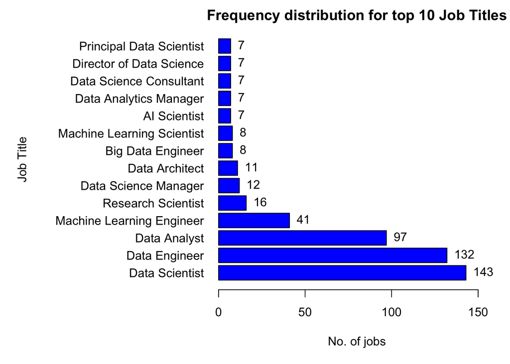

```r
# Plotting barplot
barmatrix.DBb1 <- as.matrix(DBb1)
par(mar=c(5.1, 15, 2, 1)) # used to adjust margin , shift graph to the right so job titles wont be cut off
bpJob <- barplot(DBb1$n, names.arg = DBb1$job_title,
                 col = "blue",
                 main = "Frequency distribution for top 10 Job Titles",
                 xlab = "No. of jobs",
                 horiz = TRUE,
                 xlim = c(0,160),
                 las = 1)
mtext("Job Title", side = 2, line = 13, cex.lab = 1, las = 3) # use this instead of ylab so label will not overlap names
text(x=DBb1$n, y=bpJob, col="black", DBb1$n, pos=4)
```

50 job titles.

**END: YOUR ANSWER**

### Q2.(aii) Job Information Dashboard Part 2 (6 marks)

- Create a table and pie chart for each of the following variables: `employment_type`, `experience_level`, `work_year` (6 marks)

**BEGIN: YOUR ANSWER**

```r
# Create table for employment type
DBp1 <- DB %>% count(employment_type, sort = TRUE)
kable(DBp1, caption = "Employment Type")
```

Employment Type

| employment_type | n |
| --- | --- |
| FT | 588 |
| PT | 10 |
| CT | 5 |
| FL | 4 |

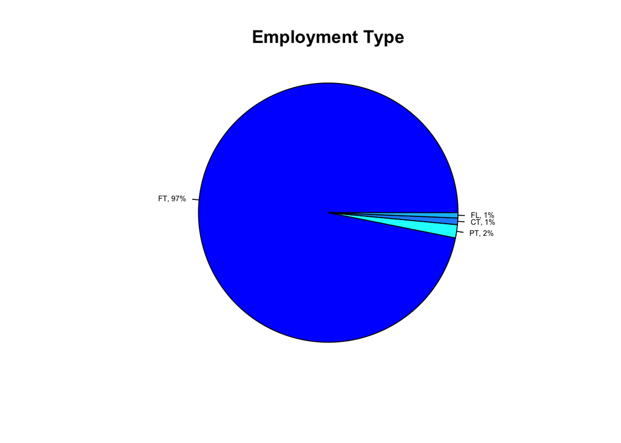

```r
# Create pie chart for employment type
slice.employment <- DBp1$n
employment.piepercent <- 100*round(DBp1$n/sum(DBp1$n),2)
label <- DBp1$employment_type
label <- paste(label, ",", sep ="")
label <- paste(label, employment.piepercent)
label <- paste(label, "%", sep = "")
pie(slice.employment,
    labels=label,
    col=c("blue","cyan","dodgerblue","deepskyblue"),
    radius=1,
    cex = 0.5, # to make labels not overlap
    main="Employment Type")
```

```r
# Create table for experience level
DBp2 <- DB %>% count(experience_level, sort = TRUE)
kable(DBp2, caption = "Experience level")
```

Experience level

| experience_level | n |
| --- | --- |
| SE | 280 |
| MI | 213 |
| EN | 88 |
| EX | 26 |

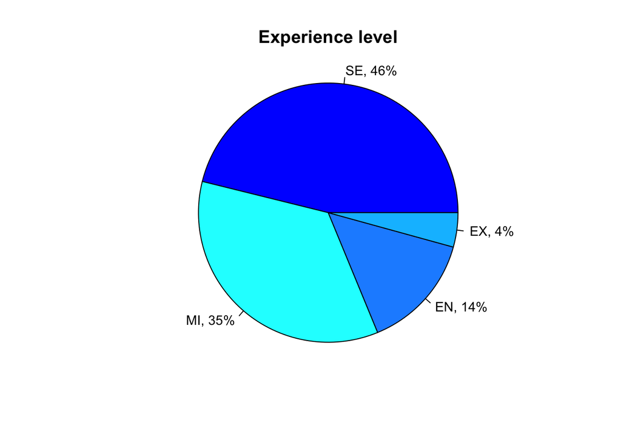

```r
# Create pie chart for experience level
slice.experience <- DBp2$n
experience.piepercent <- 100*round(DBp2$n/sum(DBp2$n),2)
label <- DBp2$experience_level
label <- paste(label, ",", sep ="")
label <- paste(label, experience.piepercent)
label <- paste(label, "%", sep = "")
pie(slice.experience,
    labels=label,
    col=c("blue","cyan","dodgerblue","deepskyblue"),
    radius=1,
    cex = 0.9,
    main="Experience level")
```

```r
# Create table for work year
DBp3 <- DB %>% count(work_year, sort = TRUE)
kable(DBp3, caption = "Work year")
```

Work year

| work_year | n |
| --- | --- |
| 2022 | 318 |
| 2021 | 217 |
| 2020 | 72 |

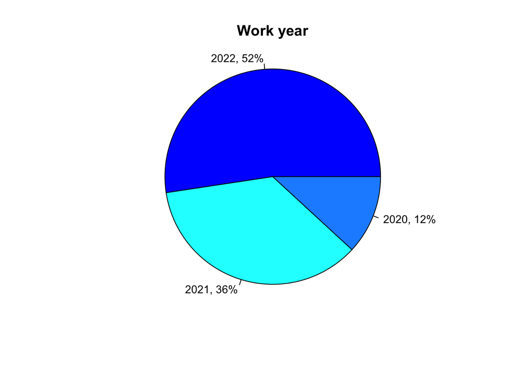

```r
# Create pie chart for work year
slice.year <- DBp3$n
year.piepercent <- 100*round(DBp3$n/sum(DBp3$n),2)
label <- DBp3$work_year
label <- paste(label, ",", sep ="")
label <- paste(label, year.piepercent)
label <- paste(label, "%", sep = "")
pie(slice.year,
    labels=label,
    col=c("blue","cyan","dodgerblue"),
    radius=1,
    cex = 0.9,
    main="Work year")
```

**END: YOUR ANSWER**

### Q2.(aiii) Job Information Dashboard Part 3 (5 marks)

- Create a table and chart to compare the frequency distributions for `employment_type` across the top 3 job titles.
- Create a table and chart to compare the frequency distributions for `experience_level` across the top 3 job titles.
- Based on charts in 2aii and 2aiii, describe briefly the type of jobs that are in the dataset. For example, is there more of a particular employment type in the data, and is the pattern the same for the top 3 job titles.
- For tutorial discussion only: What do you think about the job titles captured in the data. Do you think there are any issues with reliability or validity?

**BEGIN: YOUR ANSWER**

```r
# Create contingency table for Employment Type and Job Title
top3JobsByType <- DB %>% group_by(job_title, employment_type) %>% count()
top3JobsByType <- top3JobsByType %>% filter(job_title == "Data Scientist" |job_title == "Data Engineer" | job_title == "Data Analyst")
top3JobsByType.spread <- top3JobsByType %>% spread(key=job_title,value=n)
top3JobsByType.spread[is.na(top3JobsByType.spread)]<-0 #convert NA to 0 value
kable(top3JobsByType.spread, caption = "Contingency table for Employment Type and Job Title")
```

Contingency table for Employment Type and Job Title

| employment_type | Data Analyst | Data Engineer | Data Scientist |
| --- | --- | --- | --- |
| FL | 0 | 1 | 1 |
| FT | 96 | 129 | 140 |
| PT | 1 | 2 | 2 |

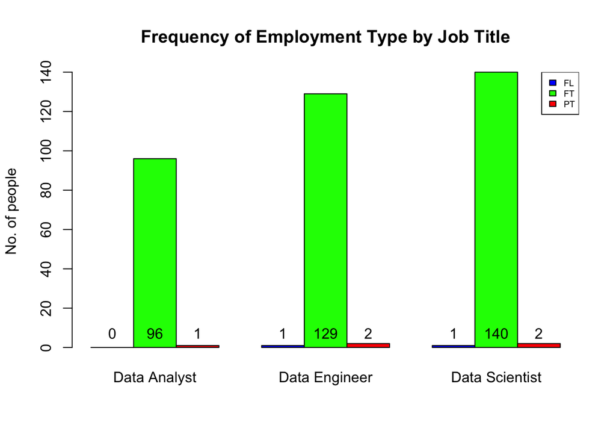

```r
#Plotting Grouped barplot for Employment Type and Job Title
barmatrix.top3JobsByType <- as.matrix(top3JobsByType.spread[,c(2:4)]) #extract and convert the 2nd to 4th columns into a matrix
bar_col1 <- c("blue", "green", "red")
bpjobem <- barplot(barmatrix.top3JobsByType, col=bar_col1,  main="Frequency of Employment Type by Job Title", ylab="No. of people", beside=TRUE)
#creating numbers in the barplot
text(bpjobem, 0, col = "black", barmatrix.top3JobsByType,cex=1, pos=3)
#legend
legend("topright", cex=0.6, fill=bar_col1, legend=top3JobsByType.spread$employment_type)
```

```r
# Create contingency table for Experience Level and Job Title
top3JobsByXp <- DB %>% group_by(job_title, experience_level) %>% count()
top3JobsByXp <- top3JobsByXp %>% filter(job_title == "Data Scientist" ||job_title == "Data Engineer" || job_title == "Data Analyst")
top3JobsByXp.spread <- top3JobsByXp %>% spread(key=job_title,value=n)
top3JobsByXp.spread[is.na(top3JobsByXp.spread)]<-0 #convert NA to 0 value
kable(top3JobsByXp.spread, caption = "Contingency table for Experience Level and Job Title")
```

Contingency table for Experience Level and Job Title

| experience_level | Data Analyst | Data Engineer | Data Scientist |
| --- | --- | --- | --- |
| EN | 12 | 12 | 22 |
| EX | 2 | 4 | 0 |
| MI | 29 | 53 | 60 |
| SE | 54 | 63 | 61 |

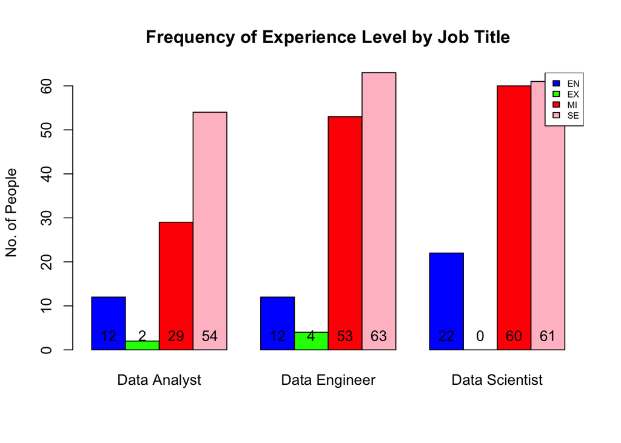

```r
#Plotting Grouped barplot for Experience Level and Job Title
barmatrix.top3JobsByXp<-as.matrix(top3JobsByXp.spread[,c(2:4)])
bar_col2 <- c("blue", "green", "red", "pink")
bpjobex <- barplot(barmatrix.top3JobsByXp, col=bar_col2,  main="Frequency of Experience Level by Job Title", ylab="No. of People", beside=TRUE)
#creating numbers in the barplot
text(bpjobex, 0, col = "black", barmatrix.top3JobsByXp,cex=1, pos=3)
#legend
legend("topright", cex=0.6, fill=bar_col2, legend=top3JobsByXp.spread$experience_level)
```

Based on charts in 2aii, there is an overwhelming majority of FT employment compared to its FL and PT counterparts. Number of PT is also always higher than number of FL employment. This pattern is the same for the top 3 job titles.  
Based on charts in 2aiii, the largest number of jobs is in the SE experience level, followed by MI, EN, and lastly EX. This pattern is the same for the top 3 job titles.

**END: YOUR ANSWER**

### Q2.(b) Salary Dashboard (10 marks)

This dashboard is to visualise the salary data captured in the dataset better.

- 1. Create a table and chart to visualise the frequency distributions for `salaryinusd`
- 2. Create separate tables and charts to visualise the frequency distributions for `salaryinusd` across the top 3 Job titles. Do you observe any difference across the 3 job titles? [HINT: you may want to use the same breaks/bin width for the 3 charts for ease of comparison]
- For tutorial discussion only: What do the round and square brackets for the intervals in the frequency distribution tables mean?

**BEGIN: YOUR ANSWER**

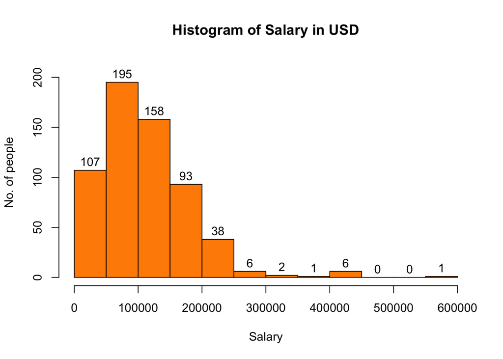

```r
# Plotting histogram for salary in USD
options(scipen=5) # to remove scientific notation
h1<-hist(DB$salary_in_usd,
                 main="Histogram of Salary in USD",
                 xlab="Salary",
                 ylab="No. of people",
                 col=c("darkorange"),
                 ylim=c(0,210),
                 breaks = seq(0,600000,length.out = 13), # set 12 intervals between 0 and 600,000
                 labels=TRUE)
```

```r
# Extract frequency table from hist()
salary.range <- cut(DB$salary_in_usd,h1$breaks,include.lowest = TRUE, dig.lab = 6)
t1 <- table(salary.range)
kable(t1, caption = "Frequency distribution by Salary in USD")
```

Frequency distribution by Salary in USD

| salary.range | Freq |
| --- | --- |
| [0,50000] | 107 |
| (50000,100000] | 195 |
| (100000,150000] | 158 |
| (150000,200000] | 93 |
| (200000,250000] | 38 |
| (250000,300000] | 6 |
| (300000,350000] | 2 |
| (350000,400000] | 1 |
| (400000,450000] | 6 |
| (450000,500000] | 0 |
| (500000,550000] | 0 |
| (550000,600000] | 1 |

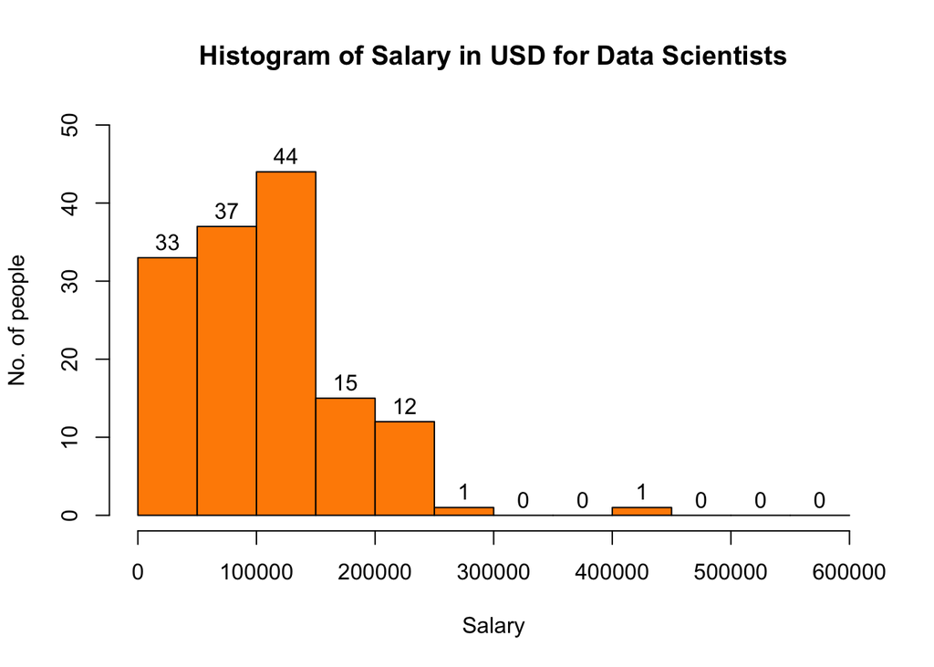

```r
# Plotting histogram for salary in USD across Data Scientist
salaryDS = DB %>% filter(job_title == "Data Scientist") %>% select(salary_in_usd)
h2<-hist(salaryDS$salary_in_usd,
                 main="Histogram of Salary in USD for Data Scientists",
                 xlab="Salary",
                 ylab="No. of people",
                 col=c("darkorange"),
                 ylim=c(0,50),
                 breaks = seq(0,600000,length.out = 13), # set 12 intervals between 0 and 600,000
                 labels=TRUE)
```

```r
# Extract frequency table from hist() for Data Scientist
salary.range.DS <- cut(salaryDS$salary_in_usd,h2$breaks,include.lowest = TRUE, dig.lab = 6)
t2 <- table(salary.range.DS)
kable(t2, caption = "Frequency distribution by Salary in USD for Data Scientists")
```

Frequency distribution by Salary in USD for Data Scientists

| salary.range.DS | Freq |
| --- | --- |
| [0,50000] | 33 |
| (50000,100000] | 37 |
| (100000,150000] | 44 |
| (150000,200000] | 15 |
| (200000,250000] | 12 |
| (250000,300000] | 1 |
| (300000,350000] | 0 |
| (350000,400000] | 0 |
| (400000,450000] | 1 |
| (450000,500000] | 0 |
| (500000,550000] | 0 |
| (550000,600000] | 0 |

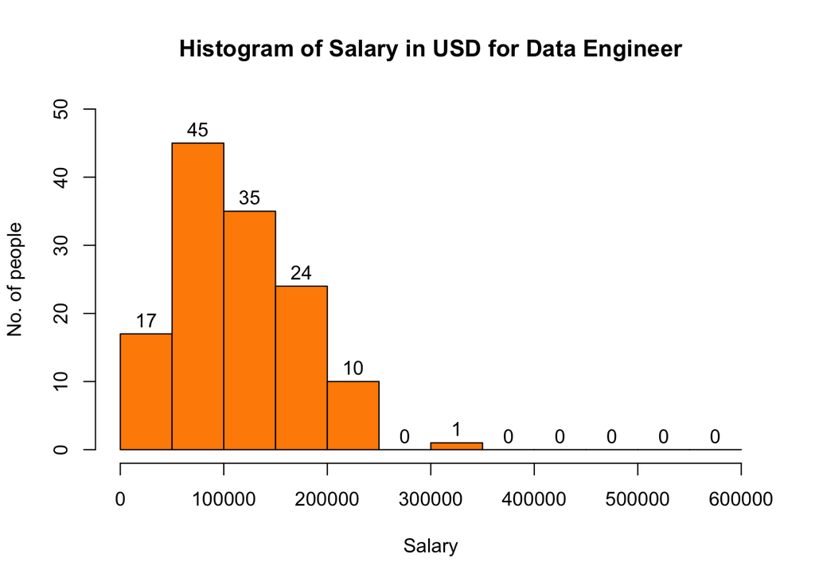

```r
# Plotting histogram for salary in USD across Data Engineer
salaryDE = DB %>% filter(job_title == "Data Engineer") %>% select(salary_in_usd)
h3<-hist(salaryDE$salary_in_usd,
                 main="Histogram of Salary in USD for Data Engineer",
                 xlab="Salary",
                 ylab="No. of people",
                 col=c("darkorange"),
                 ylim=c(0,50),
                 breaks = seq(0,600000,length.out = 13), # set 12 intervals between 0 and 600,000
                 labels=TRUE)
```

```r
# Extract frequency table from hist() for Data Engineer
salary.range.DE <- cut(salaryDE$salary_in_usd,h3$breaks, dig.lab = 6)
t3 <- table(salary.range.DE)
kable(t3, caption = "Frequency distribution by Salary in USD for Data Engineer")
```

Frequency distribution by Salary in USD for Data Engineer

| salary.range.DE | Freq |
| --- | --- |
| (0,50000] | 17 |
| (50000,100000] | 45 |
| (100000,150000] | 35 |
| (150000,200000] | 24 |
| (200000,250000] | 10 |
| (250000,300000] | 0 |
| (300000,350000] | 1 |
| (350000,400000] | 0 |
| (400000,450000] | 0 |
| (450000,500000] | 0 |
| (500000,550000] | 0 |
| (550000,600000] | 0 |

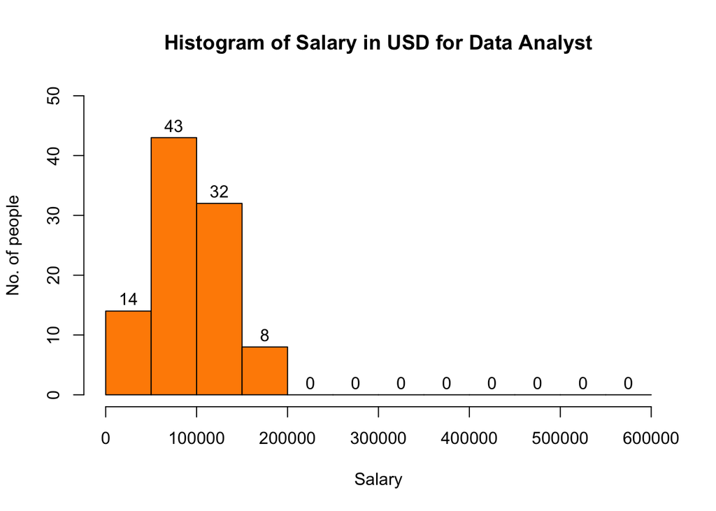

```r
# Plotting histogram for salary in USD across Data Analyst
salaryDA = DB %>% filter(job_title == "Data Analyst") %>% select(salary_in_usd)
h4<-hist(salaryDA$salary_in_usd,
                 main="Histogram of Salary in USD for Data Analyst",
                 xlab="Salary",
                 ylab="No. of people",
                 col=c("darkorange"),
                 ylim=c(0,50),
                 breaks = seq(0,600000,length.out = 13), # set 12 intervals between 0 and 600,000
                 labels=TRUE)
```

```r
# Extract frequency table from hist() for Data Analyst
salary.range.DA <- cut(salaryDE$salary_in_usd,h4$breaks, dig.lab = 6)
t4 <- table(salary.range.DA)
kable(t4, caption = "Frequency distribution by Salary in USD for Data Analyst")
```

[output not shown]

**END: YOUR ANSWER**

### Q2.(c) Interactive Contingency Table (2 marks)

Create a contingency table with the `rPivotTable` function for Data Scientist jobs that displays frequency for the following 3 variables: experience_level, employment_type and work_year.

**BEGIN: YOUR ANSWER**

```r
# Things to note: make it such that all data is already data scientist. Can use the 3 variables in both columns and rows.

DBds <- DB %>% filter(job_title == "Data Scientist")

rpivotTable(DBds,
            rows = "work_year",
            cols=c("experience_level","employment_type"),
            aggregatorName = "Count")
```

[interactive table not shown]

**END: YOUR ANSWER**

### Q2.(d) Pareto Analysis (3 marks)

Conduct a Pareto analysis on `salary_in_usd` to be displayed in this dashboard. (Hint: check the number and percentage of individuals that contribute to 80% of the total salary_in_usd earned in the dataset. Do you observe a 80-20 split? If not, what is the ratio?).

For tutorial discussion only: Try different percentages instead of 80 (say 90, 70, 60, etc.). Is there a percentage that gives you a sum of proportions closer to 100%?

**BEGIN: YOUR ANSWER**

```r
# Extract salary_in_usd row
DB.salary <- DB %>% select(salary_in_usd) %>% arrange(desc(salary_in_usd))

# Compute the percentage of salary over total salary
DB.salary$Percentage <- DB.salary$salary_in_usd/sum(DB.salary$salary_in_usd)

# Compute cumulative percentage for Total
DB.salary$Cumulative <- cumsum(DB.salary$Percentage)

# Number of individuals contributing most significantly to at least 80% total salary
which(DB.salary$Cumulative > 0.8)[1]
```

```
## [1] 352
```

```r
# Percentage of individuals contributing most significantly to at least 80% total salary
(which(DB.salary$Cumulative > 0.8)[1])/nrow(DB)
```

```
## [1] 0.5799012
```

No. From the Pareto Analysis, we see that about 352 (out of 607) of individuals contribute to 80% of the total salary_in_usd earned. It is not a 80-20 split as around 58% of individuals make up 80% of the total salary amount. The ratio is 80-58.

**END: YOUR ANSWER**